# GSVA: gene set variation analysis

Robert Castelo, Axel Klenk and Justin Guinney

Dept. of Medicine and Life Sciences, Universitat Pompeu Fabra, Barcelona, Spain  
Tempus Labs, Inc.

robert.castelo@upf.edu  
axelvolker.klenk@upf.edu  
justin.guinney@tempus.com

15 April 2024

#### Abstract

Gene set variation analysis (GSVA) is a particular type of gene set enrichment method that works on single samples and enables pathway-centric analyses of molecular data by performing a conceptually simple but powerful change in the functional unit of analysis, from genes to gene sets. The GSVA package provides the implementation of four single-sample gene set enrichment methods, concretely *zscore*, *plage*, *ssGSEA* and its own called *GSVA*. While this methodology was initially developed for gene expression data, it can be applied to other types of molecular profiling data. In this vignette we illustrate how to use the GSVA package with bulk microarray and RNA-seq expression data.

#### Package

GSVA 1.50.5

**License**: GPL (>= 2)

# 1 Quick start

*GSVA* is an R package distributed as part of the [Bioconductor](https://bioconductor.org) project. To install the package, start R and enter:

```r
install.packages("BiocManager")
BiocManager::install("GSVA")
```

Once *GSVA* is installed, it can be loaded with the following command.

```r
library(GSVA)
```

Given a gene expression data matrix, which we shall call `X`, with rows corresponding to genes and columns to samples, such as this one simulated from random Gaussian data:

```r
p <- 10000 ## number of genes
n <- 30    ## number of samples
## simulate expression values from a standard Gaussian distribution
X <- matrix(rnorm(p*n), nrow=p,
            dimnames=list(paste0("g", 1:p), paste0("s", 1:n)))
X[1:5, 1:5]
            s1          s2         s3         s4         s5
g1  0.88379637  0.33019544 -0.8702586  1.1241615  0.4505875
g2  0.71757932  0.05719395  1.2778069  1.2924047 -1.0828201
g3  0.56365253 -1.17655657 -1.2016066  0.3315212 -0.4585293
g4 -0.24874830  1.00155582  0.9666747 -1.1816972 -1.1303768
g5 -0.04971907  0.41078029  0.1582223  0.4761562 -0.8470348
```

Given a collection of gene sets stored, for instance, in a `list` object, which we shall call `gs`, with genes sampled uniformly at random without replacement into 100 different gene sets:

```r
## sample gene set sizes
gs <- as.list(sample(10:100, size=100, replace=TRUE))
## sample gene sets
gs <- lapply(gs, function(n, p)
                   paste0("g", sample(1:p, size=n, replace=FALSE)), p)
names(gs) <- paste0("gs", 1:length(gs))
```

We can calculate GSVA enrichment scores as follows. First we should build a parameter object for the desired methodology. Here we illustrate it with the GSVA algorithm of Hänzelmann, Castelo, and Guinney (2013) by calling the function `gsvaParam()`, but other parameter object constructor functions are available; see in the next section below.

```r
gsvaPar <- gsvaParam(X, gs)
gsvaPar
A GSVA::gsvaParam object
expression data:
  matrix [10000, 30]
    rows: g1, g2, ..., g10000 (10000 total)
    cols: s1, s2, ..., s30 (30 total)
using assay: none
gene sets:
  list
    names: gs1, gs2, ..., gs100 (100 total)
    unique identifiers: g6582, g2825, ..., g8848 (4130 total)
gene set size: [1, Inf]
kcdf: Gaussian
tau: 1
maxDiff: TRUE
absRanking: FALSE
```

The first argument to the `gsvaParam()` function constructing this parameter object is the gene expression data matrix, and the second is the collection of gene sets. In this example, we provide expression data and gene sets into base R *matrix* and *list* objects, respectively, to the `gsvaParam()` function, but it can take also different specialized containers that facilitate the access and manipulation of molecular and phenotype data, as well as their associated metadata.

Second, we call the `gsva()` function with the parameter object as first argument. Other additional arguments to the `gsva()` function are `verbose` to control progress reporting and `BPPPARAM` to perform calculations in parallel through the package *BiocParallel*.

```r
gsva.es <- gsva(gsvaPar, verbose=FALSE)
dim(gsva.es)
[1] 100  30
gsva.es[1:5, 1:5]
             s1          s2          s3          s4          s5
gs1  0.01184302 -0.18477867 -0.03985710 -0.05323692 -0.22596697
gs2  0.04965956  0.02417749  0.08771920 -0.23648439  0.03123195
gs3  0.40204019 -0.03548968 -0.20908293 -0.16758369 -0.03227894
gs4 -0.12284596  0.10780344 -0.06575234 -0.11729221 -0.21132327
gs5 -0.17884234  0.08170247  0.20467955 -0.04140809  0.08210603
```

# 2 Introduction

Gene set variation analysis (GSVA) provides an estimate of pathway activity by transforming an input gene-by-sample expression data matrix into a corresponding gene-set-by-sample expression data matrix. This resulting expression data matrix can be then used with classical analytical methods such as differential expression, classification, survival analysis, clustering or correlation analysis in a pathway-centric manner. One can also perform sample-wise comparisons between pathways and other molecular data types such as microRNA expression or binding data, copy-number variation (CNV) data or single nucleotide polymorphisms (SNPs).

The GSVA package provides an implementation of this approach for the following methods:

- *plage* (Tomfohr, Lu, and Kepler 2005). Pathway level analysis of gene expression (PLAGE) standardizes expression profiles over the samples and then, for each gene set, it performs a singular value decomposition (SVD) over its genes. The coefficients of the first right-singular vector are returned as the estimates of pathway activity over the samples. Note that, because of how SVD is calculated, the sign of its singular vectors is arbitrary.
- *zscore* (Lee et al. 2008). The z-score method standardizes expression profiles over the samples and then, for each gene set, combines the standardized values as follows. Given a gene set $\gamma=\{1,\dots,k\}$ with standardized values $z_1,\dots,z_k$ for each gene in a specific sample, the combined z-score $Z_\gamma$ for the gene set $\gamma$ is defined as:
  $$Z_\gamma = \frac{\sum_{i=1}^k z_i}{\sqrt{k}}\,.$$
- *ssgsea* (Barbie et al. 2009). Single sample GSEA (ssGSEA) is a non-parametric method that calculates a gene set enrichment score per sample as the normalized difference in empirical cumulative distribution functions (CDFs) of gene expression ranks inside and outside the gene set. By default, the implementation in the GSVA package follows the last step described in (Barbie et al. 2009, online methods, pg. 2) by which pathway scores are normalized, dividing them by the range of calculated values. This normalization step may be switched off using the argument `ssgsea.norm` in the call to the `gsva()` function; see below.
- *gsva* (Hänzelmann, Castelo, and Guinney 2013). This is the default method of the package and similarly to ssGSEA, is a non-parametric method that uses the empirical CDFs of gene expression ranks inside and outside the gene set, but it starts by calculating an expression-level statistic that brings gene expression profiles with different dynamic ranges to a common scale.

The interested user may find full technical details about how these methods work in their corresponding articles cited above. If you use any of them in a publication, please cite them with the given bibliographic reference.

# 3 Overview of the GSVA functionality

The workhorse of the GSVA package is the function `gsva()`, which takes a *parameter object* as its main input. There are four classes of parameter objects corresponding to the methods listed above, and may have different additional parameters to tune, but all of them require at least the following two input arguments:

1. A normalized gene expression dataset, which can be provided in one of the following containers:
   - A `matrix` of expression values with genes corresponding to rows and samples corresponding to columns.
   - An `ExpressionSet` object; see package *Biobase*.
   - A `SummarizedExperiment` object, see package *SummarizedExperiment*.
2. A collection of gene sets; which can be provided in one of the following containers:
   - A `list` object where each element corresponds to a gene set defined by a vector of gene identifiers, and the element names correspond to the names of the gene sets.
   - A `GeneSetCollection` object; see package *GSEABase*.

One advantage of providing the input data using specialized containers such as `ExpressionSet`, `SummarizedExperiment` and `GeneSetCollection` is that the `gsva()` function will automatically map the gene identifiers between the expression data and the gene sets (internally calling the function `mapIdentifiers()` from the package *GSEABase*), when they come from different standard nomenclatures, i.e., *Ensembl* versus *Entrez*, provided the input objects contain the appropriate metadata; see next section.

If either the input gene expression data is provided as a `matrix` object or the gene sets are provided in a `list` object, or both, it is then the responsibility of the user to ensure that both objects contain gene identifiers following the same standard nomenclature.

Before the actual calculations take place, the `gsva()` function will apply the following filters:

1. Discard genes in the input expression data matrix with constant expression.
2. Discard genes in the input gene sets that do not map to a gene in the input gene expression data matrix.
3. Discard gene sets that, after applying the previous filters, do not meet a minimum and maximum size, which by default is one for the minimum size and has no limit for the maximum size.

If, as a result of applying these three filters, either no genes or gene sets are left, the `gsva()` function will prompt an error. A common cause for such an error at this stage is that gene identifiers between the expression data matrix and the gene sets do not belong to the same standard nomenclature and could not be mapped. This may happen because either the input data were not provided using some of the specialized containers described above or the necessary metadata in those containers that allows the software to successfully map gene identifiers, is missing.

The method employed by the `gsva()` function is determined by the class of the parameter object that it receives as an input. An object constructed using the `gsvaParam()` function runs the method described by Hänzelmann, Castelo, and Guinney (2013), but this can be changed using the parameter constructor functions `plageParam()`, `zscoreParam()`, or `ssgseaParam()`, corresponding to the methods briefly described in the introduction; see also their corresponding help pages.

When using `gsvaParam()`, the user can additionally tune the following parameters:

- `kcdf`: The first step of the GSVA algorithm brings gene expression profiles to a common scale by calculating an expression statistic through a non-parametric estimation of the CDF across samples. Such a non-parametric estimation employs a *kernel function* and the `kcdf` parameter allows the user to specify three possible values for that function: (1) `"Gaussian"`, the default value, which is suitable for continuous expression data, such as microarray fluorescent units in logarithmic scale and RNA-seq log-CPMs, log-RPKMs or log-TPMs units of expression; (2) `"Poisson"`, which is suitable for integer counts, such as those derived from RNA-seq alignments; (3) `"none"`, which will enforce a direct estimation of the CDF without a kernel function.
- `maxDiff`: The last step of the GSVA algorithm calculates the gene set enrichment score from two Kolmogorov-Smirnov random walk statistics. This parameter is a logical flag that allows the user to specify two possible ways to do such calculation: (1) `TRUE`, the default value, where the enrichment score is calculated as the magnitude difference between the largest positive and negative random walk deviations; (2) `FALSE`, where the enrichment score is calculated as the maximum distance of the random walk from zero.
- `absRanking`: Logical flag used only when `maxDiff=TRUE`. By default, `absRanking=FALSE` and it implies that a modified Kuiper statistic is used to calculate enrichment scores, taking the magnitude difference between the largest positive and negative random walk deviations. When `absRanking=TRUE` the original Kuiper statistic is used, by which the largest positive and negative random walk deviations are added together. In this case, gene sets with genes enriched on either extreme (high or low) will be regarded as highly activated.
- `tau`: Exponent defining the weight of the tail in the random walk. By default `tau=1`.

In general, the default values for the previous parameters are suitable for most analysis settings, which usually consist of some kind of normalized continuous expression values.

# 4 Gene set definitions

Gene sets constitute a simple, yet useful, way to define pathways because we use pathway membership definitions only, neglecting the information on molecular interactions. Gene set definitions are a crucial input to any gene set enrichment analysis because if our gene sets do not capture the biological processes we are studying, we will likely not find any relevant insights in our data from an analysis based on these gene sets.

There are multiple sources of gene sets, the most popular ones being [The Gene Ontology (GO) project](http://geneontology.org) and [The Molecular Signatures Database (MSigDB)](https://www.gsea-msigdb.org/gsea/msigdb). Sometimes gene set databases will not include the ones we need. In such a case we should either curate our own gene sets or use techniques to infer them from data.

```r
class(gs)
[1] "list"
length(gs)
[1] 100
head(lapply(gs, head))
$gs1
[1] "g6582" "g2825" "g4450" "g2117" "g4946" "g5368"

$gs2
[1] "g7976" "g8312" "g4107" "g6550" "g576"  "g5485"

$gs3
[1] "g2738" "g7377" "g1533" "g1159" "g2293" "g480"

$gs4
[1] "g1059" "g3331" "g5143" "g9091" "g8589" "g4056"

$gs5
[1] "g6579" "g7125" "g2411" "g8977" "g3803" "g3334"

$gs6
[1] "g2345" "g5705" "g757"  "g8786" "g218"  "g6175"
```

Using a Bioconductor organism-level package such as *org.Hs.eg.db* we can easily build a list object containing a collection of gene sets defined as GO terms with annotated Entrez gene identifiers, as follows:

```r
library(org.Hs.eg.db)

goannot <- select(org.Hs.eg.db, keys=keys(org.Hs.eg.db), columns="GO")
head(goannot)
  ENTREZID         GO EVIDENCE ONTOLOGY
1        1 GO:0003674       ND       MF
2        1 GO:0005576      HDA       CC
3        1 GO:0005576      IDA       CC
4        1 GO:0005576      TAS       CC
5        1 GO:0005615      HDA       CC
6        1 GO:0005886      IBA       CC
genesbygo <- split(goannot$ENTREZID, goannot$GO)
length(genesbygo)
[1] 18809
head(genesbygo)
$`GO:0000002`
 [1] "291"   "1890"  "4205"  "4358"  "4976"  "9361"  "10000" "55186" "55186"
[10] "80119" "84275" "84275" "92667"

$`GO:0000003`
[1] "2796"   "2797"   "8510"   "286826"

$`GO:0000009`
[1] "55650" "79087"

$`GO:0000010`
[1] "23590" "57107"

$`GO:0000012`
 [1] "1161"      "2074"      "3981"      "7141"      "7515"      "23411"
 [7] "54840"     "54840"     "54840"     "55775"     "55775"     "200558"
[13] "100133315"

$`GO:0000014`
 [1] "2021"  "2067"  "2072"  "4361"  "4361"  "5932"  "6419"  "6419"  "9941"
[10] "10111" "64421"
```

A more sophisticated container for gene sets is the `GeneSetCollection` object class defined in the *GSEABase* package, which also provides the function `getGmt()` to import [gene matrix transposed (GMT)](http://software.broadinstitute.org/cancer/software/gsea/wiki/index.php/Data_formats#GMT:_Gene_Matrix_Transposed_file_format_.28.2A.gmt.29) files such as those provided by [MSigDB](https://www.gsea-msigdb.org/gsea/msigdb) into a `GeneSetCollection` object. The experiment data package *GSVAdata* provides one such object with the old (3.0) version of the C2 collection of curated genesets from [MSigDB](https://www.gsea-msigdb.org/gsea/msigdb), which can be loaded as follows.

```r
library(GSEABase)
library(GSVAdata)

data(c2BroadSets)
class(c2BroadSets)
[1] "GeneSetCollection"
attr(,"package")
[1] "GSEABase"
c2BroadSets
GeneSetCollection
  names: NAKAMURA_CANCER_MICROENVIRONMENT_UP, NAKAMURA_CANCER_MICROENVIRONMENT_DN, ..., ST_PHOSPHOINOSITIDE_3_KINASE_PATHWAY (3272 total)
  unique identifiers: 5167, 100288400, ..., 57191 (29340 total)
  types in collection:
    geneIdType: EntrezIdentifier (1 total)
    collectionType: BroadCollection (1 total)
```

The documentation of *GSEABase* contains a description of the `GeneSetCollection` class and its associated methods.

# 5 Quantification of pathway activity in bulk microarray and RNA-seq data

Here we illustrate how GSVA provides an analogous quantification of pathway activity in both microarray and RNA-seq data by using two such datasets that have been derived from the same biological samples. More concretely, we will use gene expression data of lymphoblastoid cell lines (LCL) from HapMap individuals that have been profiled using both technologies (Huang et al. 2007, @pickrell_understanding_2010). These data form part of the experimental package *GSVAdata* and the corresponding help pages contain details on how the data were processed. We start loading these data and verifying that they indeed contain expression data for the same genes and samples, as follows:

```r
library(Biobase)

data(commonPickrellHuang)

stopifnot(identical(featureNames(huangArrayRMAnoBatchCommon_eset),
                    featureNames(pickrellCountsArgonneCQNcommon_eset)))
stopifnot(identical(sampleNames(huangArrayRMAnoBatchCommon_eset),
                    sampleNames(pickrellCountsArgonneCQNcommon_eset)))
```

Next, for the current analysis we use the subset of canonical pathways from the C2 collection of MSigDB Gene Sets. These correspond to the following pathways from KEGG, REACTOME and BIOCARTA:

```r
canonicalC2BroadSets <- c2BroadSets[c(grep("^KEGG", names(c2BroadSets)),
                                      grep("^REACTOME", names(c2BroadSets)),
                                      grep("^BIOCARTA", names(c2BroadSets)))]
canonicalC2BroadSets
GeneSetCollection
  names: KEGG_GLYCOLYSIS_GLUCONEOGENESIS, KEGG_CITRATE_CYCLE_TCA_CYCLE, ..., BIOCARTA_ACTINY_PATHWAY (833 total)
  unique identifiers: 55902, 2645, ..., 8544 (6744 total)
  types in collection:
    geneIdType: EntrezIdentifier (1 total)
    collectionType: BroadCollection (1 total)
```

Additionally, we extend this collection of gene sets with two formed by genes with sex-specific expression, which also form part of the *GSVAdata* experiment data package. Here we use the constructor function `GeneSet` from the *GSEABase* package to build the objects that we add to the `GeneSetCollection` object `canonicalC2BroadSets`.

```r
data(genderGenesEntrez)

MSY <- GeneSet(msYgenesEntrez, geneIdType=EntrezIdentifier(),
               collectionType=BroadCollection(category="c2"),
               setName="MSY")
MSY
setName: MSY
geneIds: 266, 84663, ..., 353513 (total: 34)
geneIdType: EntrezId
collectionType: Broad
  bcCategory: c2 (Curated)
  bcSubCategory: NA
details: use 'details(object)'
XiE <- GeneSet(XiEgenesEntrez, geneIdType=EntrezIdentifier(),
               collectionType=BroadCollection(category="c2"),
               setName="XiE")
XiE
setName: XiE
geneIds: 293, 8623, ..., 1121 (total: 66)
geneIdType: EntrezId
collectionType: Broad
  bcCategory: c2 (Curated)
  bcSubCategory: NA
details: use 'details(object)'

canonicalC2BroadSets <- GeneSetCollection(c(canonicalC2BroadSets, MSY, XiE))
canonicalC2BroadSets
GeneSetCollection
  names: KEGG_GLYCOLYSIS_GLUCONEOGENESIS, KEGG_CITRATE_CYCLE_TCA_CYCLE, ..., XiE (835 total)
  unique identifiers: 55902, 2645, ..., 1121 (6810 total)
  types in collection:
    geneIdType: EntrezIdentifier (1 total)
    collectionType: BroadCollection (1 total)
```

We calculate now GSVA enrichment scores for these gene sets using first the normalized microarray data and then the normalized RNA-seq integer count data. Note that the only requirement to do the latter is to set the argument `kcdf="Poisson"`, which is `"Gaussian"` by default. Note, however, that if our RNA-seq normalized expression levels would be continuous, such as log-CPMs, log-RPKMs or log-TPMs, the default value of the `kcdf` argument should remain unchanged.

```r
huangPar <- gsvaParam(huangArrayRMAnoBatchCommon_eset, canonicalC2BroadSets,
                      minSize=5, maxSize=500)
esmicro <- gsva(huangPar)
pickrellPar <- gsvaParam(pickrellCountsArgonneCQNcommon_eset,
                         canonicalC2BroadSets, minSize=5, maxSize=500,
                         kcdf="Poisson")
esrnaseq <- gsva(pickrellPar)
```

We are going to assess how gene expression profiles correlate between microarray and RNA-seq data and compare those correlations with the ones derived at pathway level. To compare gene expression values of both technologies, we will transform first the RNA-seq integer counts into log-CPM units of expression using the `cpm()` function from the *edgeR* package.

```r
library(edgeR)

lcpms <- cpm(exprs(pickrellCountsArgonneCQNcommon_eset), log=TRUE)
```

We calculate Spearman correlations between gene expression profiles of the previous log-CPM values and the microarray RMA values.

```r
genecorrs <- sapply(1:nrow(lcpms),
                    function(i, expmicro, exprnaseq)
                      cor(expmicro[i, ], exprnaseq[i, ], method="spearman"),
                    exprs(huangArrayRMAnoBatchCommon_eset), lcpms)
names(genecorrs) <- rownames(lcpms)
```

Now calculate Spearman correlations between GSVA enrichment scores derived from the microarray and the RNA-seq data.

```r
pwycorrs <- sapply(1:nrow(esmicro),
                   function(i, esmicro, esrnaseq)
                     cor(esmicro[i, ], esrnaseq[i, ], method="spearman"),
                   exprs(esmicro), exprs(esrnaseq))
names(pwycorrs) <- rownames(esmicro)
```

Figure 1 below shows the two distributions of these correlations and we can see that GSVA enrichment scores provide an agreement between microarray and RNA-seq data comparable to the one observed between gene-level units of expression.

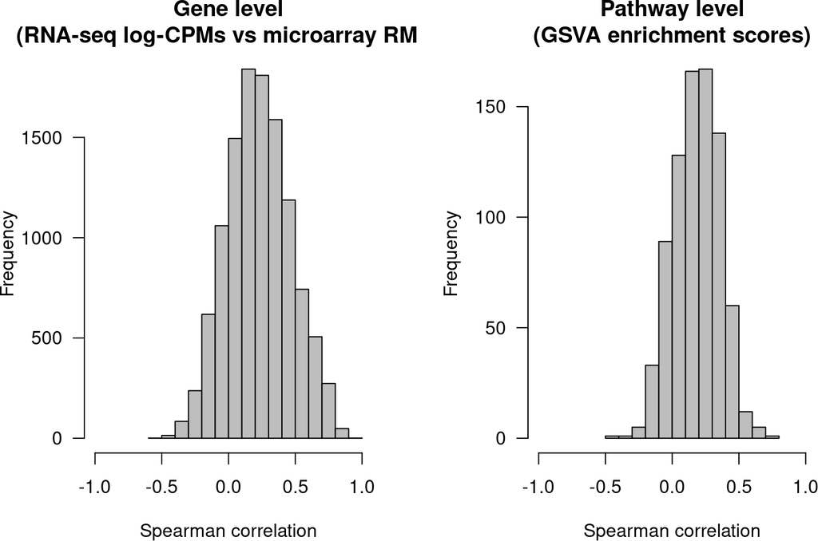

Figure 1: Comparison of correlation values of gene and pathway expression profiles derived from microarray and RNA-seq data

```r
par(mfrow=c(1, 2), mar=c(4, 5, 3, 2))
hist(genecorrs, xlab="Spearman correlation",
     main="Gene level\n(RNA-seq log-CPMs vs microarray RMA)",
     xlim=c(-1, 1), col="grey", las=1)
hist(pwycorrs, xlab="Spearman correlation",
     main="Pathway level\n(GSVA enrichment scores)",
     xlim=c(-1, 1), col="grey", las=1)
```

Finally, in Figure 2 we compare the actual GSVA enrichment scores for two gene sets formed by genes with sex-specific expression. Concretely, one gene set (XIE) formed by genes that escape chromosome X-inactivation in females (Carrel and Willard 2005) and another gene set (MSY) formed by genes located on the male-specific region of chromosome Y (Skaletsky et al. 2003).

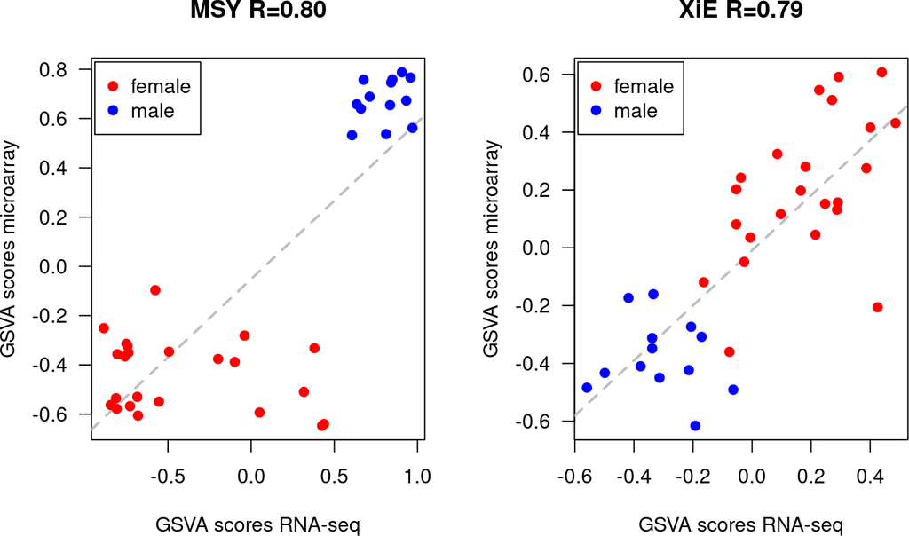

Figure 2: Comparison of GSVA enrichment scores obtained from microarray and RNA-seq data for two gene sets formed by genes with sex-specific expression

```r
par(mfrow=c(1, 2))
rmsy <- cor(exprs(esrnaseq)["MSY", ], exprs(esmicro)["MSY", ])
plot(exprs(esrnaseq)["MSY", ], exprs(esmicro)["MSY", ],
     xlab="GSVA scores RNA-seq", ylab="GSVA scores microarray",
     main=sprintf("MSY R=%.2f", rmsy), las=1, type="n")
fit <- lm(exprs(esmicro)["MSY", ] ~ exprs(esrnaseq)["MSY", ])
abline(fit, lwd=2, lty=2, col="grey")
maskPickrellFemale <- pickrellCountsArgonneCQNcommon_eset$Gender == "Female"
maskHuangFemale <- huangArrayRMAnoBatchCommon_eset$Gender == "Female"
points(exprs(esrnaseq["MSY", maskPickrellFemale]),
       exprs(esmicro)["MSY", maskHuangFemale],
       col="red", pch=21, bg="red", cex=1)
maskPickrellMale <- pickrellCountsArgonneCQNcommon_eset$Gender == "Male"
maskHuangMale <- huangArrayRMAnoBatchCommon_eset$Gender == "Male"
points(exprs(esrnaseq)["MSY", maskPickrellMale],
       exprs(esmicro)["MSY", maskHuangMale],
       col="blue", pch=21, bg="blue", cex=1)
legend("topleft", c("female", "male"), pch=21, col=c("red", "blue"),
       pt.bg=c("red", "blue"), inset=0.01)
rxie <- cor(exprs(esrnaseq)["XiE", ], exprs(esmicro)["XiE", ])
plot(exprs(esrnaseq)["XiE", ], exprs(esmicro)["XiE", ],
     xlab="GSVA scores RNA-seq", ylab="GSVA scores microarray",
     main=sprintf("XiE R=%.2f", rxie), las=1, type="n")
fit <- lm(exprs(esmicro)["XiE", ] ~ exprs(esrnaseq)["XiE", ])
abline(fit, lwd=2, lty=2, col="grey")
points(exprs(esrnaseq["XiE", maskPickrellFemale]),
       exprs(esmicro)["XiE", maskHuangFemale],
       col="red", pch=21, bg="red", cex=1)
points(exprs(esrnaseq)["XiE", maskPickrellMale],
       exprs(esmicro)["XiE", maskHuangMale],
       col="blue", pch=21, bg="blue", cex=1)
legend("topleft", c("female", "male"), pch=21, col=c("red", "blue"),
       pt.bg=c("red", "blue"), inset=0.01)
```

We can see how microarray and RNA-seq single-sample GSVA enrichment scores correlate very well in these gene sets, with $\rho=0.80$ for the male-specific gene set and $\rho=0.79$ for the female-specific gene set. Male and female samples show higher GSVA enrichment scores in their corresponding gene set.

# 6 Example applications

## 6.1 Molecular signature identification

In (Verhaak et al. 2010) four subtypes of glioblastoma multiforme (GBM) -proneural, classical, neural and mesenchymal- were identified by the characterization of distinct gene-level expression patterns. Using four gene set signatures specific to brain cell types (astrocytes, oligodendrocytes, neurons and cultured astroglial cells), derived from murine models by Cahoy et al. (2008), we replicate the analysis of Verhaak et al. (2010) by using GSVA to transform the gene expression measurements into enrichment scores for these four gene sets, without taking the sample subtype grouping into account. We start by having a quick glance to the data, which forms part of the *GSVAdata* package:

```r
data(gbm_VerhaakEtAl)
gbm_eset
ExpressionSet (storageMode: lockedEnvironment)
assayData: 11861 features, 173 samples
  element names: exprs
protocolData: none
phenoData
  rowNames: TCGA.02.0003.01A.01 TCGA.02.0010.01A.01 ...
    TCGA.12.0620.01A.01 (173 total)
  varLabels: subtype
  varMetadata: labelDescription channel
featureData: none
experimentData: use 'experimentData(object)'
Annotation:
head(featureNames(gbm_eset))
[1] "AACS"    "FSTL1"   "ELMO2"   "CREB3L1" "RPS11"   "PNMA1"
table(gbm_eset$subtype)

  Classical Mesenchymal      Neural   Proneural
         38          56          26          53
data(brainTxDbSets)
lengths(brainTxDbSets)
      astrocytic_up        astroglia_up         neuronal_up oligodendrocytic_up
                 85                  88                  98                  70
lapply(brainTxDbSets, head)
$astrocytic_up
[1] "GRHL1"   "GPAM"    "PAPSS2"  "MERTK"   "BTG1"    "SLC46A1"

$astroglia_up
[1] "BST2"     "SERPING1" "ACTA2"    "C9orf167" "C1orf31"  "ANXA4"

$neuronal_up
[1] "STXBP1"  "JPH4"    "CACNG3"  "BRUNOL6" "CLSTN2"  "FAM123C"

$oligodendrocytic_up
[1] "DCT"    "ZNF536" "GNG8"   "ELOVL6" "NR2C1"  "RCBTB1"
```

GSVA enrichment scores for the gene sets contained in `brainTxDbSets` are calculated, in this case using `mx.diff=FALSE`, as follows:

```r
gbmPar <- gsvaParam(gbm_eset, brainTxDbSets, maxDiff=FALSE)
gbm_es <- gsva(gbmPar)
```

Figure 3 shows the GSVA enrichment scores obtained for the up-regulated gene sets across the samples of the four GBM subtypes. As expected, the *neural* class is associated with the neural gene set and the astrocytic gene sets. The *mesenchymal* subtype is characterized by the expression of mesenchymal and microglial markers, thus we expect it to correlate with the astroglial gene set. The *proneural* subtype shows high expression of oligodendrocytic development genes, thus it is not surprising that the oligodendrocytic gene set is highly enriched for ths group. Interestingly, the *classical* group correlates highly with the astrocytic gene set. In summary, the resulting GSVA enrichment scores recapitulate accurately the molecular signatures from Verhaak et al. (2010).

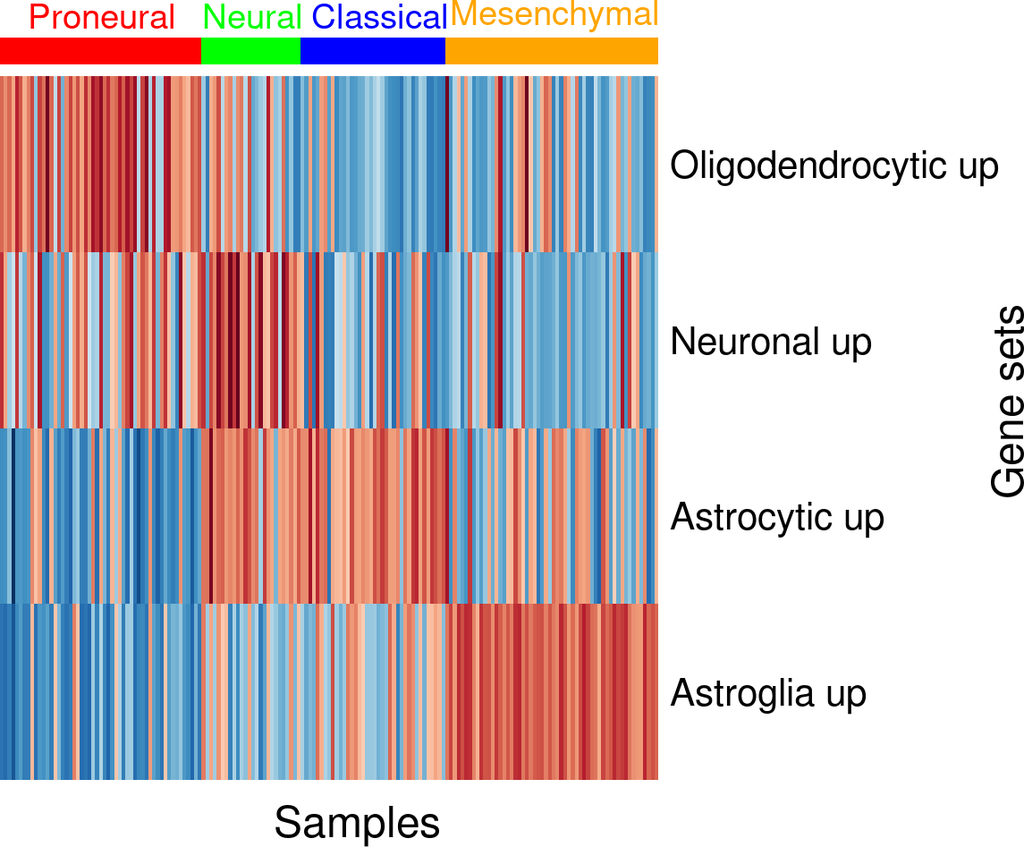

Figure 3: Heatmap of GSVA scores for cell-type brain signatures from murine models (y-axis) across GBM samples grouped by GBM subtype

```r
library(RColorBrewer)
subtypeOrder <- c("Proneural", "Neural", "Classical", "Mesenchymal")
sampleOrderBySubtype <- sort(match(gbm_es$subtype, subtypeOrder),
                             index.return=TRUE)$ix
subtypeXtable <- table(gbm_es$subtype)
subtypeColorLegend <- c(Proneural="red", Neural="green",
                        Classical="blue", Mesenchymal="orange")
geneSetOrder <- c("astroglia_up", "astrocytic_up", "neuronal_up",
                  "oligodendrocytic_up")
geneSetLabels <- gsub("_", " ", geneSetOrder)
hmcol <- colorRampPalette(brewer.pal(10, "RdBu"))(256)
hmcol <- hmcol[length(hmcol):1]

heatmap(exprs(gbm_es)[geneSetOrder, sampleOrderBySubtype], Rowv=NA,
        Colv=NA, scale="row", margins=c(3,5), col=hmcol,
        ColSideColors=rep(subtypeColorLegend[subtypeOrder],
                          times=subtypeXtable[subtypeOrder]),
        labCol="", gbm_es$subtype[sampleOrderBySubtype],
        labRow=paste(toupper(substring(geneSetLabels, 1,1)),
                     substring(geneSetLabels, 2), sep=""),
        cexRow=2, main=" \n ")
par(xpd=TRUE)
text(0.23,1.21, "Proneural", col="red", cex=1.2)
text(0.36,1.21, "Neural", col="green", cex=1.2)
text(0.47,1.21, "Classical", col="blue", cex=1.2)
text(0.62,1.21, "Mesenchymal", col="orange", cex=1.2)
mtext("Gene sets", side=4, line=0, cex=1.5)
mtext("Samples          ", side=1, line=4, cex=1.5)
```

## 6.2 Differential expression at pathway level

We illustrate here how to conduct a differential expression analysis at pathway level. We will use an example gene expression microarray data from Armstrong et al. (2002), which consists of 37 different individuals with human acute leukemia, where 20 of them have conventional childhood acute lymphoblastic leukemia (ALL) and the other 17 are affected with the MLL (mixed-lineage leukemia gene) translocation. This leukemia data set is stored as an `ExpressionSet` object called `leukemia` in the *GSVAdata* package and and details on how the data was pre-processed can be found in the corresponding help page. Jointly with the RMA expression values, we provide some metadata including the main phenotype corresponding to the leukemia sample subtype.

```r
data(leukemia)
leukemia_eset
ExpressionSet (storageMode: lockedEnvironment)
assayData: 12626 features, 37 samples
  element names: exprs
protocolData
  sampleNames: CL2001011101AA.CEL CL2001011102AA.CEL ...
    CL2001011152AA.CEL (37 total)
  varLabels: ScanDate
  varMetadata: labelDescription
phenoData
  sampleNames: CL2001011101AA.CEL CL2001011102AA.CEL ...
    CL2001011152AA.CEL (37 total)
  varLabels: subtype
  varMetadata: labelDescription channel
featureData: none
experimentData: use 'experimentData(object)'
Annotation: hgu95a
```

Next, we calculate GSVA enrichment scores using a subset of gene sets from the MSigDB C2 collection that represent signatures of genetic and chemical perturbations (CGP), and setting the the minimum and maximum gene set size to 10 and 500 genes, respectively.

```r
cgpC2BroadSets <- c2BroadSets[c(grep("_UP$", names(c2BroadSets)),
                                grep("_DN$", names(c2BroadSets)))]
cgpC2BroadSets
leukPar <- gsvaParam(leukemia_eset, cgpC2BroadSets,
                     minSize=10, maxSize=500)
leukemia_es <- gsva(leukPar)
```

The object returned by the function `gsva()` is always of the same class as the input object with the expression data. Therefore, in this case, we obtain an `ExpressionSet` object with features corresponding to gene sets.

```r
class(leukemia_es)
[1] "ExpressionSet"
attr(,"package")
[1] "Biobase"
leukemia_es
ExpressionSet (storageMode: lockedEnvironment)
assayData: 1305 features, 37 samples
  element names: exprs
protocolData: none
phenoData
  sampleNames: CL2001011101AA.CEL CL2001011102AA.CEL ...
    CL2001011152AA.CEL (37 total)
  varLabels: subtype
  varMetadata: labelDescription channel
featureData: none
experimentData: use 'experimentData(object)'
Annotation:
head(featureNames(leukemia_es))
[1] "NAKAMURA_CANCER_MICROENVIRONMENT_UP"
[2] "WEST_ADRENOCORTICAL_TUMOR_MARKERS_UP"
[3] "WINTER_HYPOXIA_UP"
[4] "PYEON_HPV_POSITIVE_TUMORS_UP"
[5] "NAKAMURA_TUMOR_ZONE_PERIPHERAL_VS_CENTRAL_UP"
[6] "PICCALUGA_ANGIOIMMUNOBLASTIC_LYMPHOMA_UP"
```

We will perform now a differential expression analysis using *limma* (Smyth 2004) between the two different leukemia subtypes.

```r
library(limma)

mod <- model.matrix(~ factor(leukemia_es$subtype))
colnames(mod) <- c("ALL", "MLLvsALL")
fit <- lmFit(leukemia_es, mod)
fit <- eBayes(fit)
res <- decideTests(fit, p.value=0.01)
summary(res)
        ALL MLLvsALL
Down      0       21
NotSig 1305     1255
Up        0       29
```

As Figure 4 below shows, GSVA scores have higher precision for larger gene sets.

Thanks to Gordon Smyth for point this out to us.

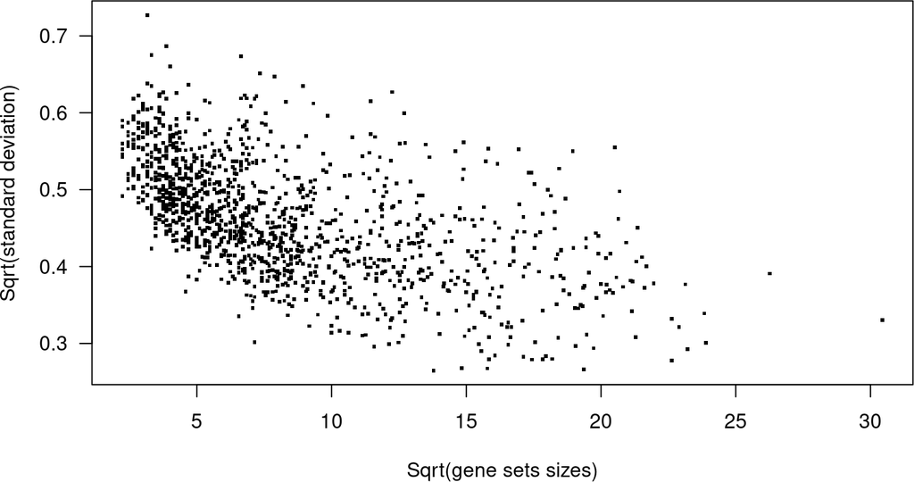

Figure 4: Residual standard deviation of GSVA scores as function of gene set size

```r
gssizes <- lengths(geneIds(cgpC2BroadSets)) ## fetch gene set sizes
mt <- match(rownames(leukemia_es), names(gssizes))
gssizes <- gssizes[mt] ## rearrange gene set sizes to the rows of GSVA scores
plot(sqrt(gssizes), sqrt(fit$sigma), xlab="Sqrt(gene sets sizes)",
     ylab="Sqrt(standard deviation)", las=1, pch=".", cex=3)
```

In such a setting, we can improve the analysis of differentially expressed pathways by using the limma-trend approach (Phipson et al. 2016) setting the `trend` parameter in the call to the `eBayes()` function to the vector of gene set sizes, in one-to-one correspondence with the gene sets in the rows of the GSVA scores container, as calculated before in `gssizes`.

```r
fit <- eBayes(fit, trend=gssizes)
res <- decideTests(fit, p.value=0.01)
summary(res)
        ALL MLLvsALL
Down      0       20
NotSig 1305     1258
Up        0       27
```

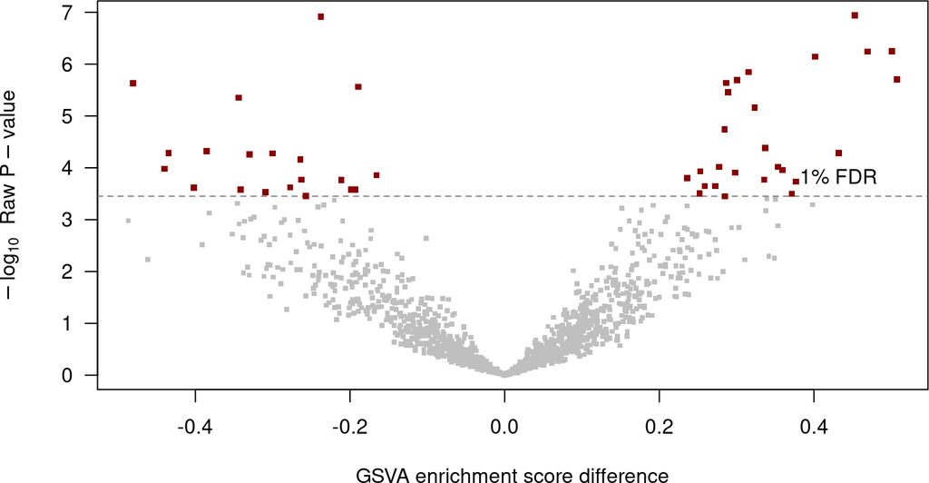

Figure 5: Volcano plot for the differential expression analysis at pathway level between two leukemia subtypes

```r
tt <- topTable(fit, coef=2, n=Inf)
DEpwys <- rownames(tt)[tt$adj.P.Val <= 0.01]
plot(tt$logFC, -log10(tt$P.Value), pch=".", cex=4, col=grey(0.75),
     main="", xlab="GSVA enrichment score difference", las=1,
     ylab=expression(-log[10]~~Raw~P-value))
abline(h=-log10(max(tt$P.Value[tt$adj.P.Val <= 0.01])),
       col=grey(0.5), lwd=1, lty=2)
points(tt$logFC[match(DEpwys, rownames(tt))],
       -log10(tt$P.Value[match(DEpwys, rownames(tt))]),
       pch=".", cex=5, col="darkred")
text(max(tt$logFC)*0.85, -log10(max(tt$P.Value[tt$adj.P.Val <= 0.01])),
     "1% FDR", pos=3)
```

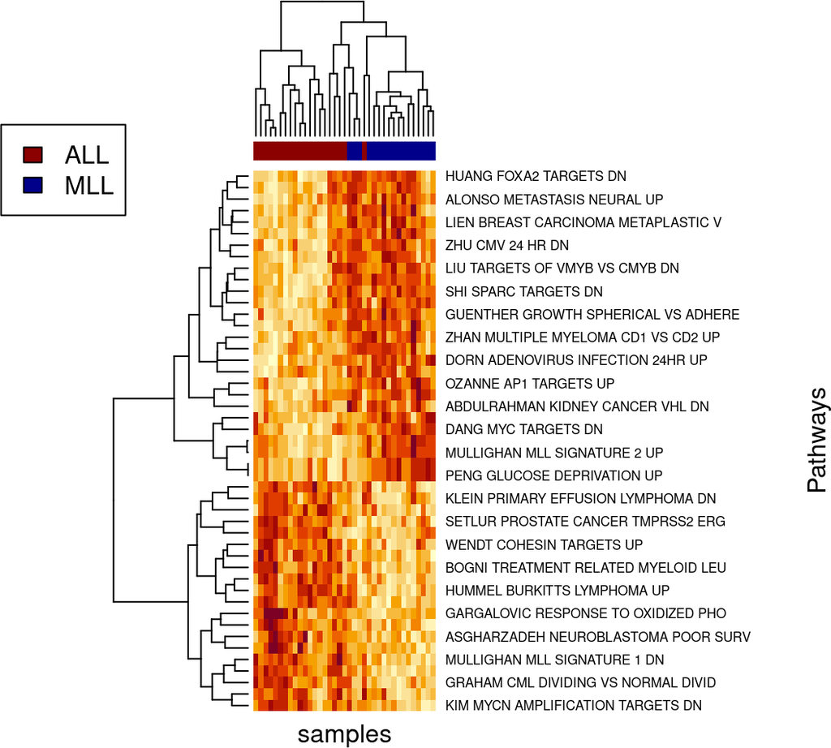

Figure 6: Heatmap of GSVA enrichment scores for the differentially expressed pathways between two leukemia subtypes

```r
DEpwys_es <- exprs(leukemia_es[DEpwys, ])
colorLegend <- c("darkred", "darkblue")
names(colorLegend) <- c("ALL", "MLL")
sample.color.map <- colorLegend[pData(leukemia_es)[, "subtype"]]
names(sample.color.map) <- colnames(DEpwys_es)
sampleClustering <- hclust(as.dist(1-cor(DEpwys_es, method="spearman")),
                           method="complete")
geneSetClustering <- hclust(as.dist(1-cor(t(DEpwys_es), method="pearson")),
                            method="complete")
heatmap(DEpwys_es, ColSideColors=sample.color.map, xlab="samples",
        ylab="Pathways", margins=c(2, 20),
        labRow=substr(gsub("_", " ", gsub("^KEGG_|^REACTOME_|^BIOCARTA_", "",
                                          rownames(DEpwys_es))), 1, 35),
        labCol="", scale="row", Colv=as.dendrogram(sampleClustering),
        Rowv=as.dendrogram(geneSetClustering))
legend("topleft", names(colorLegend), fill=colorLegend, inset=0.01, bg="white")
```

# 7 Interactive web app

The `gsva()` function can be also used through an interactive web app developed with *shiny*. To start it just type on the R console:

```r
res <- igsva()
```

It will open your browser with the web app shown here below. The button `SAVE & CLOSE` will close the app and return the resulting object on the R console. Hence, the need to call igsva() on the right-hand side of an assignment if you want to store the result in your workspace. Alternatively, you can use the `DOWNLOAD` button to download the result in a CSV file.

[figure not shown]

In the starting window of the web app, after running GSVA, a non-parametric kernel density estimation of sample profiles of GSVA scores will be shown. By clicking on one of the lines, the cumulative distribution of GSVA scores for the corresponding samples will be shown in the `GeneSets` tab, as illustrated in the image below.

[figure not shown]

# 8 Contributing

GSVA has benefited from contributions by multiple developers, see https://github.com/rcastelo/GSVA/graphs/contributors for a list of them. Contributions to the software codebase of GSVA are welcome as long as contributors abide to the terms of the [Bioconductor Contributor Code of Conduct](https://bioconductor.org/about/code-of-conduct). If you want to contribute to the development of GSVA please open an [issue](https://github.com/rcastelo/GSVA/issues) to start discussing your suggestion or, in case of a bugfix or a straightforward feature, directly a [pull request](https://github.com/rcastelo/GSVA/pulls).

# Session information

Here is the output of `sessionInfo()` on the system on which this document was compiled running pandoc 2.7.3:

```r
sessionInfo()
R version 4.3.3 (2024-02-29)
Platform: x86_64-pc-linux-gnu (64-bit)
Running under: Ubuntu 22.04.4 LTS

Matrix products: default
BLAS:   /home/biocbuild/bbs-3.18-bioc/R/lib/libRblas.so
LAPACK: /usr/lib/x86_64-linux-gnu/lapack/liblapack.so.3.10.0

locale:
 [1] LC_CTYPE=en_US.UTF-8       LC_NUMERIC=C
 [3] LC_TIME=en_GB              LC_COLLATE=C
 [5] LC_MONETARY=en_US.UTF-8    LC_MESSAGES=en_US.UTF-8
 [7] LC_PAPER=en_US.UTF-8       LC_NAME=C
 [9] LC_ADDRESS=C               LC_TELEPHONE=C
[11] LC_MEASUREMENT=en_US.UTF-8 LC_IDENTIFICATION=C

time zone: America/New_York
tzcode source: system (glibc)

attached base packages:
[1] stats4    stats     graphics  grDevices utils     datasets  methods
[8] base

other attached packages:
 [1] RColorBrewer_1.1-3   edgeR_4.0.16         limma_3.58.1
 [4] GSVAdata_1.38.0      hgu95a.db_3.13.0     GSEABase_1.64.0
 [7] graph_1.80.0         annotate_1.80.0      XML_3.99-0.16.1
[10] org.Hs.eg.db_3.18.0  AnnotationDbi_1.64.1 IRanges_2.36.0
[13] S4Vectors_0.40.2     Biobase_2.62.0       BiocGenerics_0.48.1
[16] GSVA_1.50.5          BiocStyle_2.30.0

loaded via a namespace (and not attached):
 [1] blob_1.2.4                  Biostrings_2.70.3
 [3] bitops_1.0-7                fastmap_1.1.1
 [5] SingleCellExperiment_1.24.0 RCurl_1.98-1.14
 [7] digest_0.6.35               rsvd_1.0.5
 [9] lifecycle_1.0.4             statmod_1.5.0
[11] KEGGREST_1.42.0             RSQLite_2.3.6
[13] magrittr_2.0.3              compiler_4.3.3
[15] rlang_1.1.3                 sass_0.4.9
[17] tools_4.3.3                 yaml_2.3.8
[19] knitr_1.46                  S4Arrays_1.2.1
[21] bit_4.0.5                   DelayedArray_0.28.0
[23] abind_1.4-5                 BiocParallel_1.36.0
[25] HDF5Array_1.30.1            grid_4.3.3
[27] beachmat_2.18.1             xtable_1.8-4
[29] Rhdf5lib_1.24.2             tinytex_0.50
[31] SummarizedExperiment_1.32.0 cli_3.6.2
[33] rmarkdown_2.26              crayon_1.5.2
[35] httr_1.4.7                  DelayedMatrixStats_1.24.0
[37] DBI_1.2.2                   cachem_1.0.8
[39] rhdf5_2.46.1                splines_4.3.3
[41] zlibbioc_1.48.2             parallel_4.3.3
[43] BiocManager_1.30.22         XVector_0.42.0
[45] matrixStats_1.3.0           vctrs_0.6.5
[47] Matrix_1.6-5                jsonlite_1.8.8
[49] bookdown_0.39               BiocSingular_1.18.0
[51] bit64_4.0.5                 irlba_2.3.5.1
[53] magick_2.8.3                locfit_1.5-9.9
[55] jquerylib_0.1.4             codetools_0.2-20
[57] GenomeInfoDb_1.38.8         GenomicRanges_1.54.1
[59] ScaledMatrix_1.10.0         htmltools_0.5.8.1
[61] rhdf5filters_1.14.1         GenomeInfoDbData_1.2.11
[63] R6_2.5.1                    sparseMatrixStats_1.14.0
[65] evaluate_0.23               lattice_0.22-6
[67] highr_0.10                  png_0.1-8
[69] memoise_2.0.1               bslib_0.7.0
[71] Rcpp_1.0.12                 SparseArray_1.2.4
[73] xfun_0.43                   MatrixGenerics_1.14.0
[75] pkgconfig_2.0.3
```

# References

Armstrong, Scott A, Jane E Staunton, Lewis B Silverman, Rob Pieters, Monique L den Boer, Mark D Minden, Stephen E Sallan, Eric S Lander, Todd R Golub, and Stanley J Korsmeyer. 2002. “MLL Translocations Specify a Distinct Gene Expression Profile That Distinguishes a Unique Leukemia.” *Nature Gen.* 30 (1): 41–47. https://doi.org/10.1038/ng765.

Barbie, David A., Pablo Tamayo, Jesse S. Boehm, So Young Kim, Susan E. Moody, Ian F. Dunn, Anna C. Schinzel, et al. 2009. “Systematic RNA Interference Reveals That Oncogenic KRAS-driven Cancers Require TBK1.” *Nature* 462 (7269): 108–12. https://doi.org/10.1038/nature08460.

Cahoy, John D., Ben Emery, Amit Kaushal, Lynette C. Foo, Jennifer L. Zamanian, Karen S. Christopherson, Yi Xing, et al. 2008. “A Transcriptome Database for Astrocytes, Neurons, and Oligodendrocytes: A New Resource for Understanding Brain Development and Function.” *J. Neurosci.* 28 (1): 264–78. https://doi.org/10.1523/JNEUROSCI.4178-07.2008.

Carrel, Laura, and Huntington F Willard. 2005. “X-Inactivation Profile Reveals Extensive Variability in X-Linked Gene Expression in Females.” *Nature* 434 (7031): 400–404.

Hänzelmann, Sonja, Robert Castelo, and Justin Guinney. 2013. “GSVA: Gene Set Variation Analysis for Microarray and RNA-Seq Data.” *BMC Bioinformatics* 14: 7. https://doi.org/10.1186/1471-2105-14-7.

Huang, R Stephanie, Shiwei Duan, Wasim K Bleibel, Emily O Kistner, Wei Zhang, Tyson A Clark, Tina X Chen, et al. 2007. “A Genome-Wide Approach to Identify Genetic Variants That Contribute to Etoposide-Induced Cytotoxicity.” *Proceedings of the National Academy of Sciences of the United States of America* 104 (23): 9758–63.

Lee, Eunjung, Han-Yu Chuang, Jong-Won Kim, Trey Ideker, and Doheon Lee. 2008. “Inferring Pathway Activity Toward Precise Disease Classification.” *PLOS Comput Biol* 4 (11): e1000217. https://doi.org/10.1371/journal.pcbi.1000217.

Phipson, Belinda, Stanley Lee, Ian J Majewski, Warren S Alexander, and Gordon K Smyth. 2016. “Robust Hyperparameter Estimation Protects Against Hypervariable Genes and Improves Power to Detect Differential Expression.” *The Annals of Applied Statistics* 10 (2): 946. https://doi.org/10.1214/16-AOAS920.

Pickrell, Joseph K., John C. Marioni, Athma A. Pai, Jacob F. Degner, Barbara E. Engelhardt, Everlyne Nkadori, Jean-Baptiste Veyrieras, Matthew Stephens, Yoav Gilad, and Jonathan K. Pritchard. 2010. “Understanding Mechanisms Underlying Human Gene Expression Variation with RNA Sequencing.” *Nature* 464 (7289): 768–72.

Skaletsky, Helen, Tomoko Kuroda-Kawaguchi, Patrick J. Minx, Holland S. Cordum, LaDeana Hillier, Laura G. Brown, Sjoerd Repping, et al. 2003. “The Male-Specific Region of the Human Y Chromosome Is a Mosaic of Discrete Sequence Classes.” *Nature* 423 (6942): 825–37.

Smyth, Gordon K. 2004. “Linear Models and Empirical Bayes Methods for Assessing Differential Expression in Microarray Experiments.” *Stat Appl Genet Mol Biol* 3: Article3. https://doi.org/10.2202/1544-6115.1027.

Tomfohr, John, Jun Lu, and Thomas B Kepler. 2005. “Pathway Level Analysis of Gene Expression Using Singular Value Decomposition.” *BMC Bioinformatics* 6 (September): 225. https://doi.org/10.1186/1471-2105-6-225.

Verhaak, Roel G W, Katherine A Hoadley, Elizabeth Purdom, Victoria Wang, Yuan Qi, Matthew D Wilkerson, C Ryan Miller, et al. 2010. “Integrated Genomic Analysis Identifies Clinically Relevant Subtypes of Glioblastoma Characterized by Abnormalities in PDGFRA, IDH1, EGFR, and NF1.” *Cancer Cell* 17 (1): 98–110. https://doi.org/10.1016/j.ccr.2009.12.020.